# `ols_step_backward_p`

Stepwise backward regression

#### Description

Build regression model from a set of candidate predictor variables by removing predictors based on p values, in a stepwise manner until there is no variable left to remove any more.

#### Usage

```
ols_step_backward_p(model, ...)
## Default S3 method:
ols_step_backward_p(model, prem = 0.3, details = FALSE, ...)
## S3 method for class 'ols_step_backward_p'
plot(x, model = NA, ...)
```

#### Arguments

- `model`: An object of class lm; the model should include all candidate predictor variables.
- `...`: Other inputs.
- `prem`: p value; variables with p more than prem will be removed from the model.
- `details`: Logical; if TRUE, will print the regression result at each step.
- `x`: An object of class `ols_step_backward_p`.

#### Value

ols_step_backward_p returns an object of class “ols_step_backward_p”.

An object of class “ols_step_backward_p” is a list containing the following components:

- `model`: final model; an object of class lm
- `steps`: total number of steps
- `removed`: variables removed from the model
- `rsquare`: coefficient of determination
- `aic`: akaike information criteria
- `sbic`: sawa bayesian information criteria
- `sbc`: schwarz bayes information criteria
- `adjr`: adjusted r-square
- `rmse`: root mean square error
- `mallows_cp`: mallow’s Cp
- `indvar`: predictors

#### Examples

```r
# stepwise backward regression
model <- lm(y ~ ., data = surgical)
ols_step_backward_p(model)
```

```
## Backward Elimination Method
## ---------------------------
##
## Candidate Terms:
##
## 1 . bcs
## 2 . pindex
## 3 . enzyme_test
## 4 . liver_test
## 5 . age
## 6 . gender
## 7 . alc_mod
## 8 . alc_heavy
##
## We are eliminating variables based on p value...
##
## Variables Removed:
##
## - alc_mod
## - gender
## - age
##
## No more variables satisfy the condition of p value = 0.3
##
##
## Final Model Output
## ------------------
##
##                           Model Summary
## -----------------------------------------------------------------
## R                       0.884       RMSE                 195.454
## R-Squared               0.781       Coef. Var             27.839
## Adj. R-Squared          0.758       MSE                38202.426
## Pred R-Squared          0.700       MAE                  137.656
## -----------------------------------------------------------------
##  RMSE: Root Mean Square Error
##  MSE: Mean Square Error
##  MAE: Mean Absolute Error
##
##                                  ANOVA
## -----------------------------------------------------------------------
##                    Sum of
##                   Squares        DF    Mean Square      F         Sig.
## -----------------------------------------------------------------------
## Regression    6535804.090         5    1307160.818    34.217    0.0000
## Residual      1833716.447        48      38202.426
## Total         8369520.537        53
## -----------------------------------------------------------------------
##
##                                       Parameter Estimates
## ------------------------------------------------------------------------------------------------
##       model         Beta    Std. Error    Std. Beta      t        Sig         lower       upper
## ------------------------------------------------------------------------------------------------
## (Intercept)    -1178.330       208.682                 -5.647    0.000    -1597.914    -758.746
##         bcs       59.864        23.060        0.241     2.596    0.012       13.498     106.230
##      pindex        8.924         1.808        0.380     4.935    0.000        5.288      12.559
## enzyme_test        9.748         1.656        0.521     5.887    0.000        6.419      13.077
##  liver_test       58.064        40.144        0.156     1.446    0.155      -22.652     138.779
##   alc_heavy      317.848        71.634        0.314     4.437    0.000      173.818     461.878
## ------------------------------------------------------------------------------------------------
```

```
##
##
##                            Elimination Summary
## --------------------------------------------------------------------------
##         Variable                  Adj.
## Step    Removed     R-Square    R-Square     C(p)       AIC         RMSE
## --------------------------------------------------------------------------
##    1    alc_mod       0.7818      0.7486    7.0141    734.4068    199.2637
##    2    gender        0.7814      0.7535    5.0870    732.4942    197.2921
##    3    age           0.7809      0.7581    3.1925    730.6204    195.4544
## --------------------------------------------------------------------------
```

```r
# stepwise backward regression plot
model <- lm(y ~ ., data = surgical)
k <- ols_step_backward_p(model)
```

```
## Backward Elimination Method
## ---------------------------
##
## Candidate Terms:
##
## 1 . bcs
## 2 . pindex
## 3 . enzyme_test
## 4 . liver_test
## 5 . age
## 6 . gender
## 7 . alc_mod
## 8 . alc_heavy
##
## We are eliminating variables based on p value...
##
## Variables Removed:
##
## - alc_mod
## - gender
## - age
##
## No more variables satisfy the condition of p value = 0.3
##
##
## Final Model Output
## ------------------
##
##                           Model Summary
## -----------------------------------------------------------------
## R                       0.884       RMSE                 195.454
## R-Squared               0.781       Coef. Var             27.839
## Adj. R-Squared          0.758       MSE                38202.426
## Pred R-Squared          0.700       MAE                  137.656
## -----------------------------------------------------------------
##  RMSE: Root Mean Square Error
##  MSE: Mean Square Error
##  MAE: Mean Absolute Error
##
##                                  ANOVA
## -----------------------------------------------------------------------
##                    Sum of
##                   Squares        DF    Mean Square      F         Sig.
## -----------------------------------------------------------------------
## Regression    6535804.090         5    1307160.818    34.217    0.0000
## Residual      1833716.447        48      38202.426
## Total         8369520.537        53
## -----------------------------------------------------------------------
##
##                                       Parameter Estimates
## ------------------------------------------------------------------------------------------------
##       model         Beta    Std. Error    Std. Beta      t        Sig         lower       upper
## ------------------------------------------------------------------------------------------------
## (Intercept)    -1178.330       208.682                 -5.647    0.000    -1597.914    -758.746
##         bcs       59.864        23.060        0.241     2.596    0.012       13.498     106.230
##      pindex        8.924         1.808        0.380     4.935    0.000        5.288      12.559
## enzyme_test        9.748         1.656        0.521     5.887    0.000        6.419      13.077
##  liver_test       58.064        40.144        0.156     1.446    0.155      -22.652     138.779
##   alc_heavy      317.848        71.634        0.314     4.437    0.000      173.818     461.878
## ------------------------------------------------------------------------------------------------
```

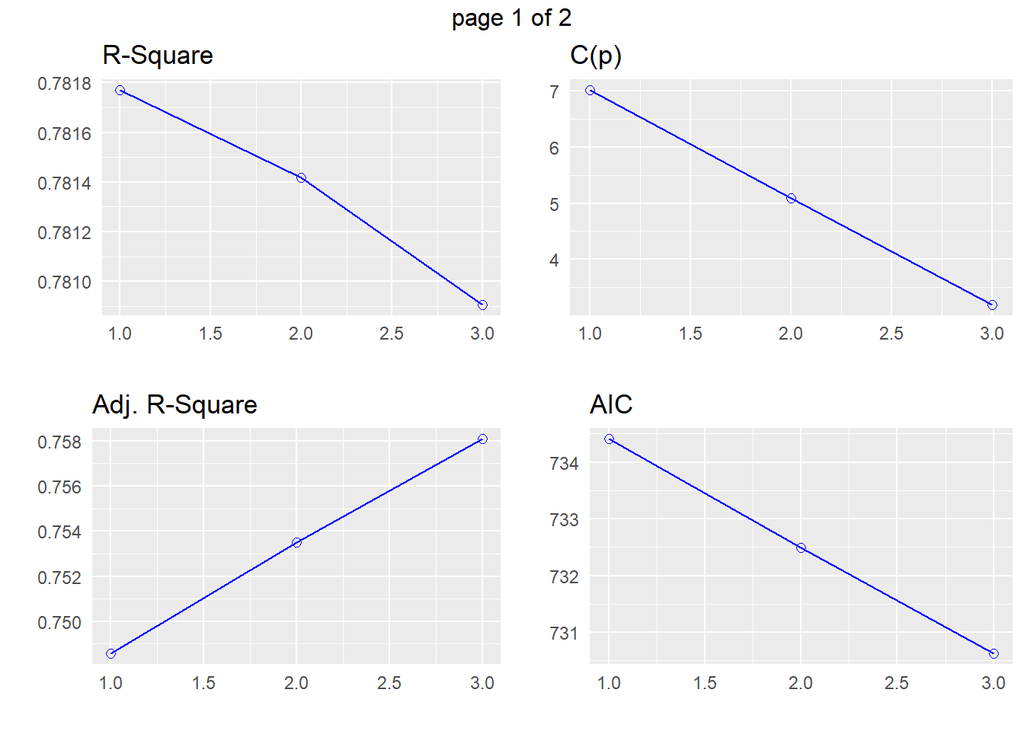

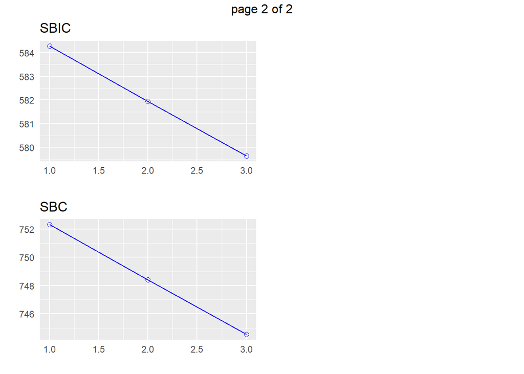

```r
plot(k)
```

```r
# final model
k$model
```

```
##
## Call:
## lm(formula = paste(response, "~", paste(preds, collapse = " + ")),
##     data = l)
##
## Coefficients:
## (Intercept)          bcs       pindex  enzyme_test   liver_test
##   -1178.330       59.864        8.924        9.748       58.064
##   alc_heavy
##     317.848
```

#### Deprecated Function

ols_step_backward() has been deprecated. Instead use ols_step_backward_p().

#### References

Chatterjee, Samprit and Hadi, Ali. Regression Analysis by Example. 5th ed. N.p.: John Wiley & Sons, 2012. Print. See Also Other variable selection procedures: ols_step_all_possible, ols_step_backward_aic, ols_step_best_subset, ols_step_both_aic, ols_step_forward_aic, ols_step_forward_p